# BUS 316 - Final Project

Alex Wolff

2023-12-13

### Load Packages

```r
library(tidyverse)
library(lubridate)
library(knitr)
library(RMySQL)
options(scipen = 999)
```

### Load Data

```r
salary_data <- read.csv("https://ballenger.wlu.edu/bus316/State_University_Salary_Data_AY_2015-16.csv")
```

### Explore Data

```r
str(salary_data)
```

```
## 'data.frame':    12287 obs. of  13 variables:
##  $ name    : chr  "AARON, NANCY G" "ABARBANELL, JEFFERY S" "ABARE, BETSY" "ABATE, AARON B" ...
##  $ dept    : chr  "Romance Languages" "Kenan-Flagler Business School" "Institute of Marine Sciences" "Medicine Administration" ...
##  $ position: chr  "Senior Lecturer" "Associate Professor" "Research Technician" "Accounting Technician" ...
##  $ exempt2 : chr  "Exempt" "Exempt" "Subject to State Personnel Act" "Subject to State Personnel Act" ...
##  $ employed: int  9 9 12 12 12 12 12 12 12 12 ...
##  $ hiredate: int  20030701 19990101 20110912 20090420 20120103 20051003 19960923 20130401 19870101 20120702 ...
##  $ fte     : num  1 1 1 1 1 1 1 1 1 1 ...
##  $ status  : chr  "Fixed-Term" "Continuing" "Permanent" "Permanent" ...
##  $ stservyr: int  11 17 3 5 2 15 34 11 27 2 ...
##  $ statesal: int  46350 173000 0 0 41696 56588 41707 0 0 0 ...
##  $ nonstsal: int  0 0 38170 50070 0 4412 0 80227 55803 32889 ...
##  $ totalsal: int  46350 173000 38170 50070 41696 61000 41707 80227 55803 32889 ...
##  $ age     : int  55 57 54 29 35 41 62 36 64 26 ...
```

```r
summary(salary_data)
```

```
##      name               dept             position           exempt2
##  Length:12287       Length:12287       Length:12287       Length:12287
##  Class :character   Class :character   Class :character   Class :character
##  Mode  :character   Mode  :character   Mode  :character   Mode  :character
##
##
##
##     employed        hiredate             fte          status
##  Min.   : 9.00   Min.   :19570901   Min.   :0.00   Length:12287
##  1st Qu.:12.00   1st Qu.:20010701   1st Qu.:1.00   Class :character
##  Median :12.00   Median :20070901   Median :1.00   Mode  :character
##  Mean   :11.64   Mean   :20050068   Mean   :0.97
##  3rd Qu.:12.00   3rd Qu.:20120618   3rd Qu.:1.00
##  Max.   :12.00   Max.   :20140929   Max.   :1.00
##     stservyr        statesal         nonstsal         totalsal
##  Min.   : 0.00   Min.   :     0   Min.   :     0   Min.   :  3000
##  1st Qu.: 4.00   1st Qu.:     0   1st Qu.:     0   1st Qu.: 41884
##  Median : 9.00   Median :  2696   Median : 38239   Median : 59342
##  Mean   :10.68   Mean   : 31372   Mean   : 49567   Mean   : 80938
##  3rd Qu.:15.00   3rd Qu.: 50000   3rd Qu.: 64763   3rd Qu.: 92865
##  Max.   :57.00   Max.   :520000   Max.   :625686   Max.   :819069
##       age
##  Min.   :21.00
##  1st Qu.:37.00
##  Median :46.00
##  Mean   :46.32
##  3rd Qu.:56.00
##  Max.   :89.00
```

### Check Data

```r
salary_data %>%
  distinct(dept) %>%
  arrange(dept)
```

### Question 1

```r
salary_data <- salary_data %>%
  rename(state_service_yrs = stservyr,
         state_salary = statesal,
         non_state_salary = nonstsal,
         total_salary = totalsal)

str(salary_data)
```

```
## 'data.frame':    12287 obs. of  13 variables:
##  $ name             : chr  "AARON, NANCY G" "ABARBANELL, JEFFERY S" "ABARE, BETSY" "ABATE, AARON B" ...
##  $ dept             : chr  "Romance Languages" "Kenan-Flagler Business School" "Institute of Marine Sciences" "Medicine Administration" ...
##  $ position         : chr  "Senior Lecturer" "Associate Professor" "Research Technician" "Accounting Technician" ...
##  $ exempt2          : chr  "Exempt" "Exempt" "Subject to State Personnel Act" "Subject to State Personnel Act" ...
##  $ employed         : int  9 9 12 12 12 12 12 12 12 12 ...
##  $ hiredate         : int  20030701 19990101 20110912 20090420 20120103 20051003 19960923 20130401 19870101 20120702 ...
##  $ fte              : num  1 1 1 1 1 1 1 1 1 1 ...
##  $ status           : chr  "Fixed-Term" "Continuing" "Permanent" "Permanent" ...
##  $ state_service_yrs: int  11 17 3 5 2 15 34 11 27 2 ...
##  $ state_salary     : int  46350 173000 0 0 41696 56588 41707 0 0 0 ...
##  $ non_state_salary : int  0 0 38170 50070 0 4412 0 80227 55803 32889 ...
##  $ total_salary     : int  46350 173000 38170 50070 41696 61000 41707 80227 55803 32889 ...
##  $ age              : int  55 57 54 29 35 41 62 36 64 26 ...
```

### Question 2

```r
mean_total_salary <- mean(salary_data$total_salary[salary_data$dept == "Neurosurgery"])

result_1 <- data.frame(mean_total_salary = mean_total_salary)
result_2 <- data.frame(dept = "Neurosurgery", mean_total_salary = mean_total_salary)

kable(result_1)
```

| mean_total_salary |
| --- |
| 380058.1 |

```r
kable(result_2)
```

| dept | mean_total_salary |
| --- | --- |
| Neurosurgery | 380058.1 |

### Question 3

```r
fulltime <- salary_data[salary_data$fte == 1,
                        c("name", "dept", "age", "status",
                          "state_salary", "non_state_salary",
                          "total_salary")]
kable(fulltime %>%
        slice(1:15))
```

| name | dept | age | status | state_salary | non_state_salary | total_salary |
| --- | --- | --- | --- | --- | --- | --- |
| AARON, NANCY G | Romance Languages | 55 | Fixed-Term | 46350 | 0 | 46350 |
| ABARBANELL, JEFFERY S | Kenan-Flagler Business School | 57 | Continuing | 173000 | 0 | 173000 |
| ABARE, BETSY | Institute of Marine Sciences | 54 | Permanent | 0 | 38170 | 38170 |
| ABATE, AARON B | Medicine Administration | 29 | Permanent | 0 | 50070 | 50070 |
| ABATEMARCO, JODI M | School of Education | 35 | Permanent | 41696 | 0 | 41696 |
| ABBOTT-LUNSFORD, SHELBY L | Medicine Administration | 41 | Permanent | 56588 | 4412 | 61000 |
| ABBOTTS, WILLIAM C | Biology | 62 | Permanent | 41707 | 0 | 41707 |
| ABDOULAYI, SARA M | Carolina Population Center | 36 | Continuing | 0 | 80227 | 80227 |
| ABDULLAH, LUBNA | Cys Fibrosis/Pulmonary Res | 64 | Continuing | 0 | 55803 | 55803 |
| ABE, PAIGE | Housing Res Education | 26 | Continuing | 0 | 32889 | 32889 |
| ABELS, KIMBERLY T | Writing Center | 51 | Continuing | 107400 | 0 | 107400 |
| ABERG, CERESA M | Human Resources | 41 | Permanent | 54445 | 18555 | 73000 |
| ABERNATHY, PENELOPE M | Journalism/Mass Communication | 63 | Continuing | 101706 | 50094 | 151800 |
| ABLE, HARRIET | School of Education | 60 | Continuing | 89356 | 9929 | 99285 |
| ABOYADE-COLE, AYOOLA A | Comprehensive Cancer Center | 36 | Permanent | 0 | 57854 | 57854 |

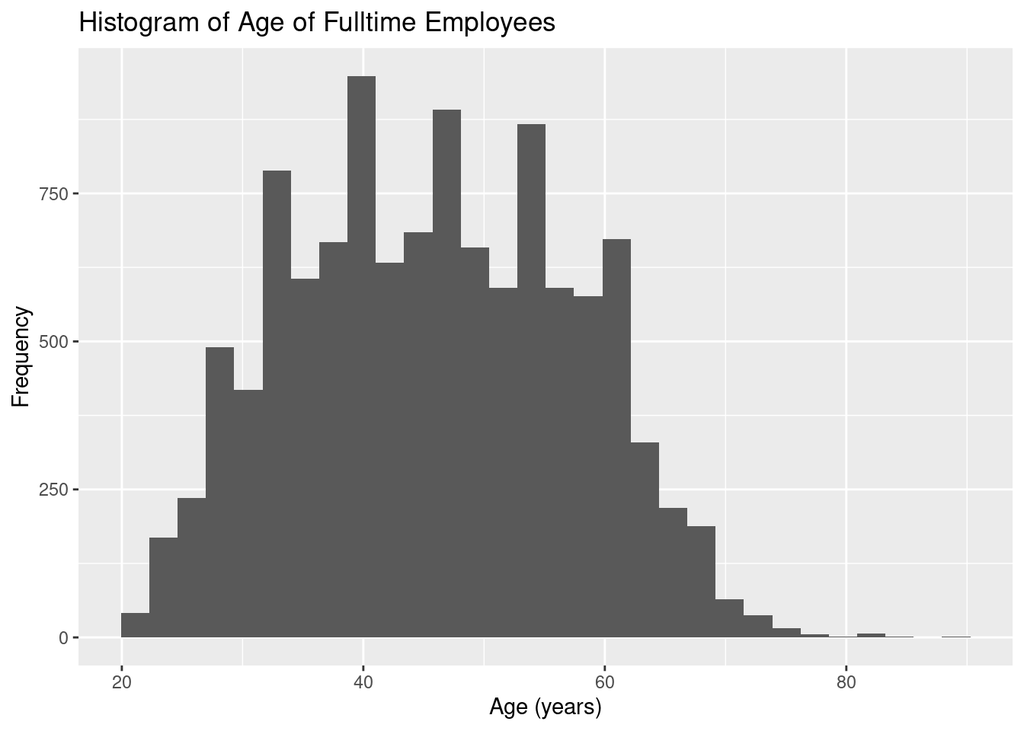

```r
ggplot(data = fulltime, aes(x = age)) +
  geom_histogram() +
  labs(title = "Histogram of Age of Fulltime Employees",
       x = "Age (years)",
       y = "Frequency")
```

The distribution of age is unimodal and slightly skewed to the right

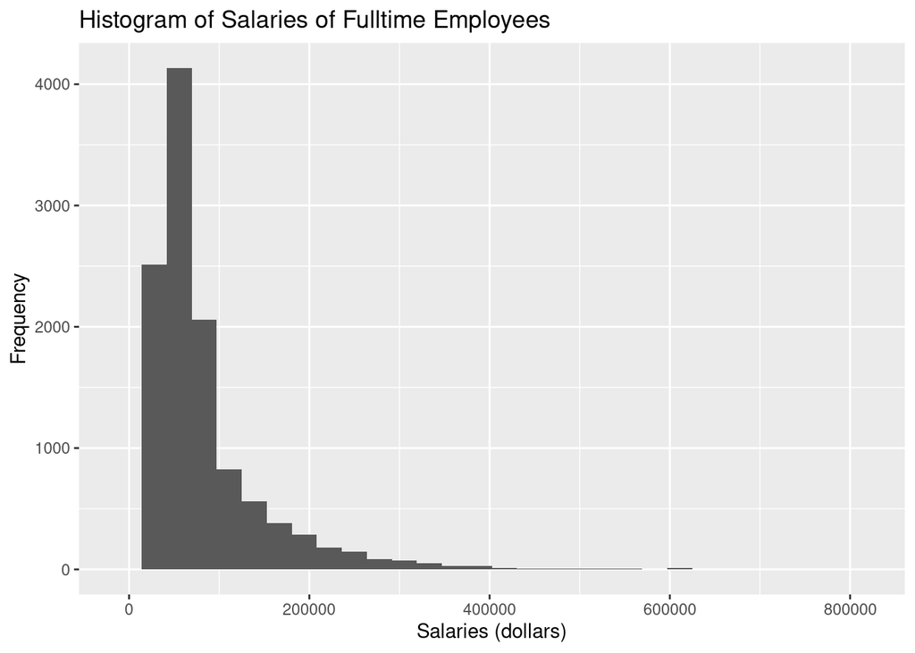

```r
ggplot(data = fulltime, aes(x = total_salary)) +
  geom_histogram() +
  labs(title = "Histogram of Salaries of Fulltime Employees",
       x = "Salaries (dollars)",
       y = "Frequency")
```

This graph shows an exponential distribution that goes off the left. The graph is right skewed.

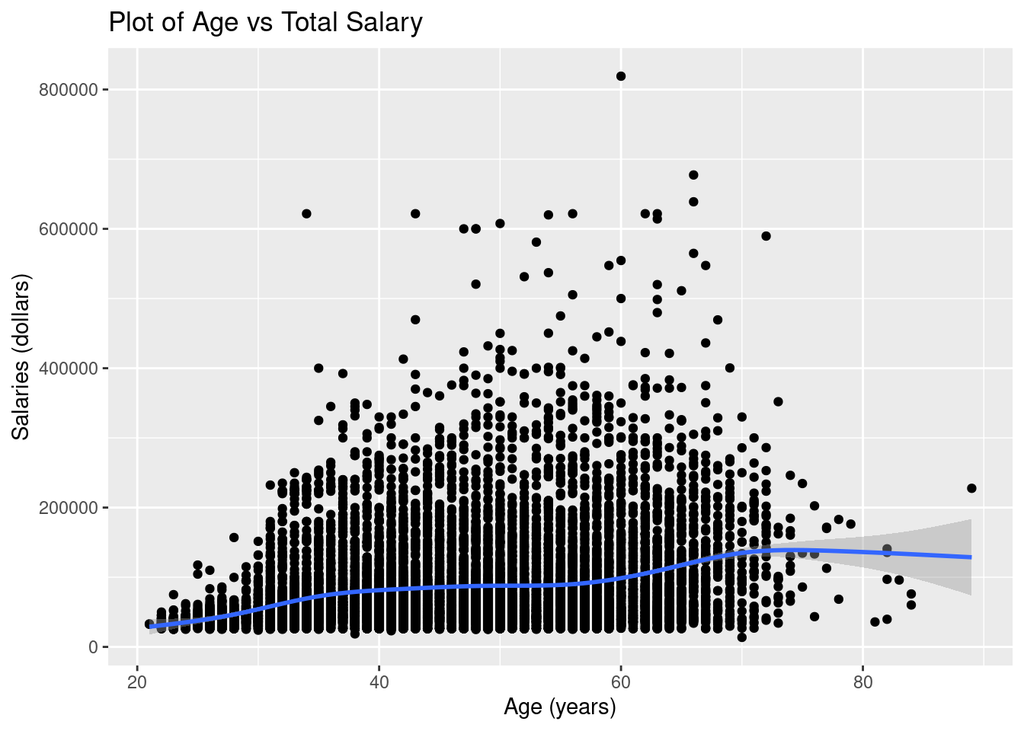

```r
ggplot(data = fulltime, aes(x = age, y=total_salary)) +
  geom_point() +
  geom_smooth() +
  labs(title = "Plot of Age vs Total Salary",
       x = "Age (years)",
       y = "Salaries (dollars)")
```

The graph shows a slight positive trend with age and salary. Hence, as the age increase the salary also increases on average.

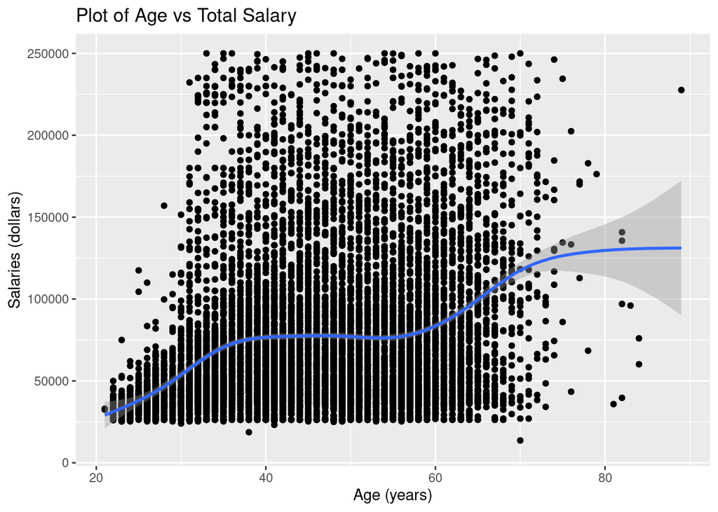

```r
ggplot(data = fulltime, aes(x = age, y=total_salary)) +
  geom_point() +
  geom_smooth() +
  ylim(10000, 250000) +
  labs(title = "Plot of Age vs Total Salary",
       x = "Age (years)",
       y = "Salaries (dollars)")
```

### Question 4

```r
kable(fulltime %>%
        filter(dept == "Neurosurgery" & total_salary > 500000))
```

| name | dept | age | status | state_salary | non_state_salary | total_salary |
| --- | --- | --- | --- | --- | --- | --- |
| CAMPBELL, DENNIS M | Neurosurgery | 34 | Fixed-Term | 0 | 621722 | 621722 |
| CARSON, LARRY V | Neurosurgery | 63 | Fixed-Term | 0 | 621722 | 621722 |
| EWEND, MATTHEW G | Neurosurgery | 50 | Continuing | 0 | 607648 | 607648 |
| JAUFMANN, BRUCE P | Neurosurgery | 56 | Fixed-Term | 0 | 621722 | 621722 |
| KILPATRICK, MICHAUX R | Neurosurgery | 43 | Fixed-Term | 0 | 621722 | 621722 |
| WADON, CAROL M | Neurosurgery | 56 | Fixed-Term | 0 | 505390 | 505390 |

These professor are paid well due to the nature of the field they work in. To become a neurosurgeon takes multiple years of medical school and is therefore very difficult to attain that title. Since the market of neurosurgery professors is very limited they get paid highly.

### Question 5

```r
radiology_dept <- fulltime %>%
  filter(dept == "Radiology") %>%
  arrange(desc(total_salary))

kable(radiology_dept %>%
        slice(1:10))
```

| name | dept | age | status | state_salary | non_state_salary | total_salary |
| --- | --- | --- | --- | --- | --- | --- |
| MAURO, MATTHEW A | Radiology | 63 | Continuing | 0 | 614176 | 614176 |
| LEE, JOSEPH K | Radiology | 67 | Continuing | 0 | 375000 | 375000 |
| BURKE, CHARLES T | Radiology | 44 | Fixed-Term | 0 | 365000 | 365000 |
| MOLINA, PAUL L | Radiology | 56 | Continuing | 15745 | 334255 | 350000 |
| STAVAS, JOSEPH M | Radiology | 59 | Fixed-Term | 0 | 345000 | 345000 |
| DIXON, ROBERT G | Radiology | 55 | Fixed-Term | 0 | 335000 | 335000 |
| CASTILLO, MAURICIO | Radiology | 55 | Continuing | 15745 | 316255 | 332000 |
| SEMELKA, RICHARD C | Radiology | 54 | Continuing | 15745 | 306255 | 322000 |
| SMITH, J K | Radiology | 52 | Continuing | 17813 | 292187 | 310000 |
| FIELDING, JULIA R | Radiology | 53 | Continuing | 15745 | 294005 | 309750 |

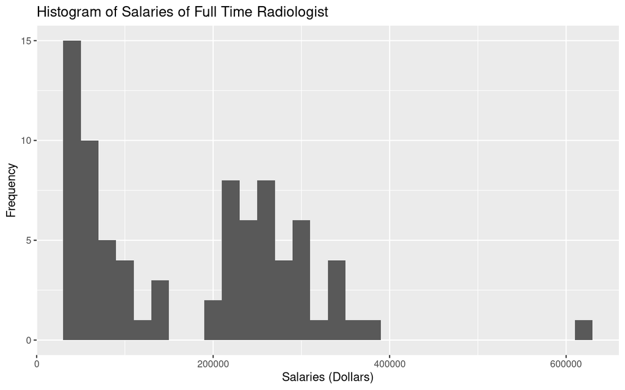

```r
ggplot(data = radiology_dept, aes(x = total_salary)) +
  geom_histogram(binwidth = 20000) +
  labs(title = "Histogram of Salaries of Full Time Radiologist",
       x = "Salaries (Dollars)",
       y = "Frequency")
```

The distribution of the salaries is bimodal and is skewed to the right. There are outliers on the upper extremities of the graph. Based of the graph, there is most likely a base salary for radiologist as they enter the field which is represented in the first hump of this graph. Then as they advance in their career and maybe specialize in different diagnosis there salary increase, which would be the second hump. The bimodal nature of the graph is due to the progression of careers in this field. Furthermore, the distribution of the of the radiologist salaries could also be due to the positions they hole. For example, technicians, which are considered radiologist are paid less than than professor, which furhter explains the distribution of the graph.

### Question 6

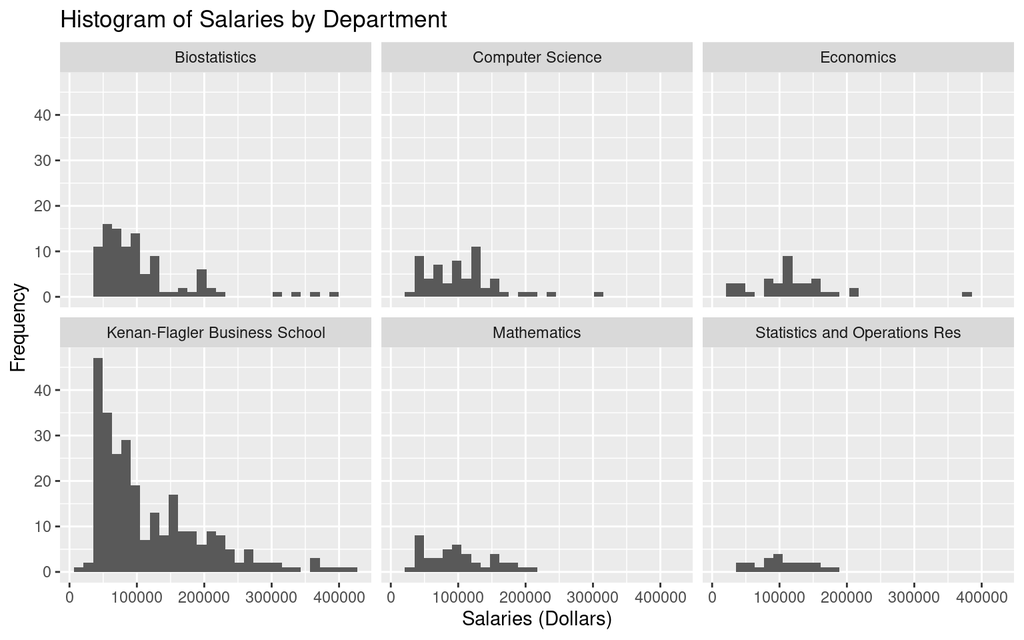

```r
fulltime %>%
  filter(dept %in% c("Biostatistics",
                     "Computer Science",
                     "Economics",
                     "Kenan-Flagler Business School",
                     "Mathematics",
                     "Statistics and Operations Res")) %>%
  ggplot(aes(x = total_salary)) +
        geom_histogram() +
        facet_wrap(~ dept) +
        labs(title = "Histogram of Salaries by Department",
             x = "Salaries (Dollars)",
             y = "Frequency")
```

There appear to be only small differences in the distribution of salaries across the 6 departments except for the Kenan-Flagler Business School. All the other graphs are unimodal and have a median around 100000; Computer Science and Biostatistics have very slight right skew. The Kenan-Flagler Business School is exponentially distributed going up the left side of the histogram; the graph is right skewed.

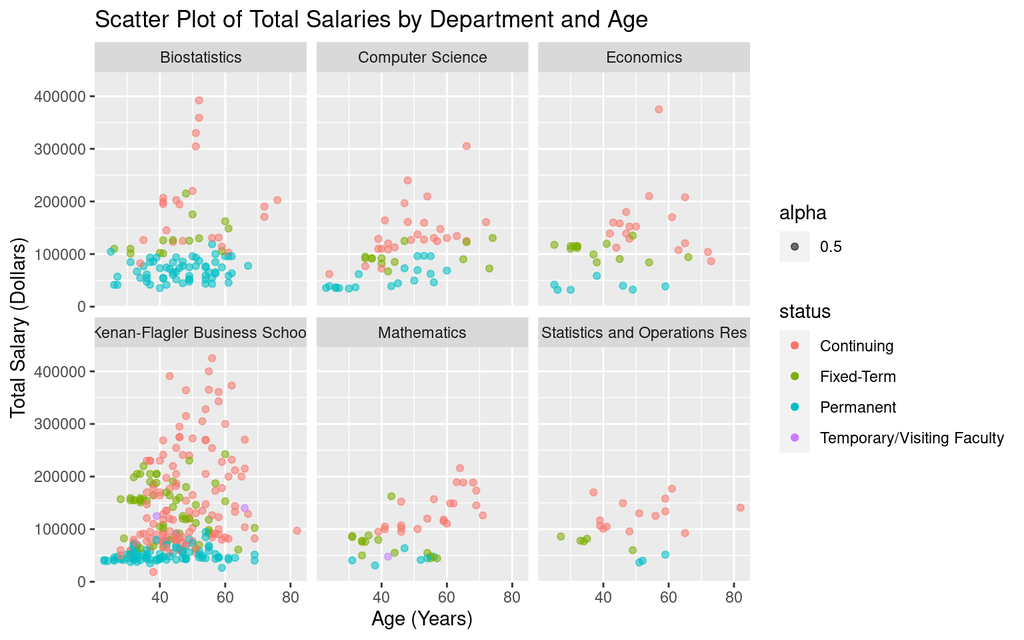

```r
fulltime %>%
  filter(dept %in% c("Biostatistics",
                     "Computer Science",
                     "Economics",
                     "Kenan-Flagler Business School",
                     "Mathematics",
                     "Statistics and Operations Res")) %>%
  ggplot(aes(x = age, y = total_salary, color = status, alpha = 0.5)) +
    geom_point() +
    facet_wrap(~ dept) +
    labs(title = "Scatter Plot of Total Salaries by Department and Age",
          x = "Age (Years)",
          y = "Total Salary (Dollars)")
```

### Question 7

```r
dept_summary <- salary_data %>%
  group_by(dept) %>%
  summarise(department_size = n(),
            mean_department_salary = mean(total_salary),
            median_department_salary = median(total_salary),
            maximum_salary = max(total_salary))

top_dept_mean <- dept_summary %>%
  select(dept, mean_department_salary) %>%
  arrange(desc(mean_department_salary)) %>%
  slice(1:10)

top_dept_median <- dept_summary %>%
  select(dept, median_department_salary) %>%
  arrange(desc(median_department_salary)) %>%
  slice(1:10)

kable(top_dept_mean)
```

| dept | mean_department_salary |
| --- | --- |
| Neurosurgery | 380058.1 |
| Provost | 273790.0 |
| Urology | 216291.1 |
| Orthopaedics | 216205.4 |
| Surgery | 201917.4 |
| Anesthesiology | 187177.4 |
| Radiation Oncology | 183044.7 |
| Carolina Counts | 182160.0 |
| Radiology | 172053.1 |
| Office of the Chancellor | 164746.7 |

```r
kable(top_dept_median)
```

| dept | median_department_salary |
| --- | --- |
| Neurosurgery | 395550 |
| Provost | 240080 |
| Orthopaedics | 240000 |
| Urology | 237500 |
| Anesthesiology | 222645 |
| Carolina Counts | 182160 |
| Radiation Oncology | 180000 |
| Surgery | 176083 |
| University Ombuds Office | 157127 |
| Ath Basketball Office | 150000 |

These lists differ due to variance in department salaries. For, examples, when there are a few professors in certain department with much higher salaries than the norm, they lift the mean salary of that department while leaving the median salary largely the same. Hence, there can differences when looking at the top ten median and mean department salaries. I would use median as it is more representative of a standard departmental salary due to prior mention of the possibility of the mean being inflated.

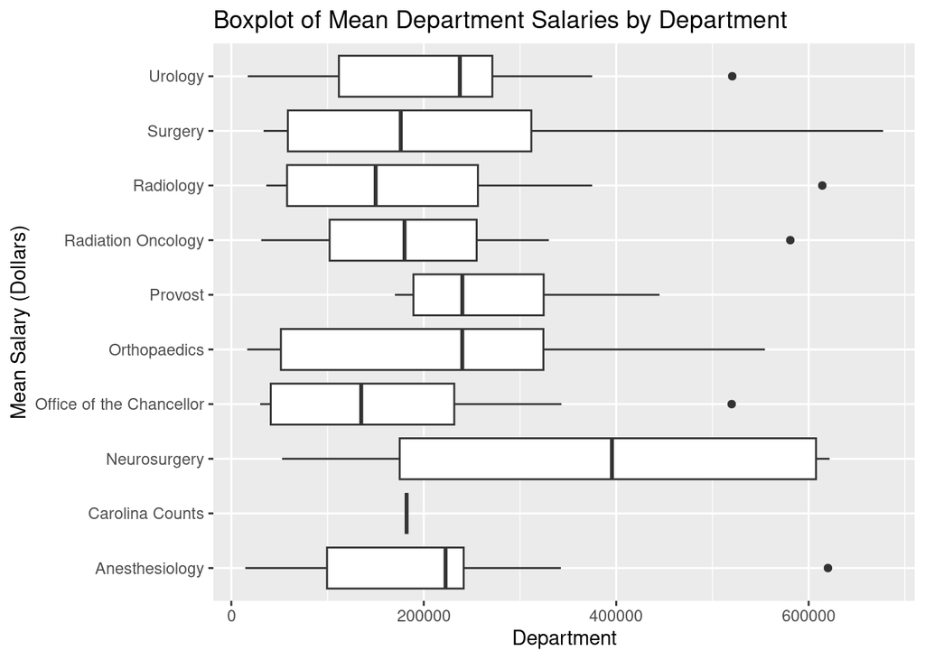

```r
salary_data %>%
  filter(dept %in% top_dept_mean$dept) %>%
  ggplot(aes(x = total_salary, y = dept )) +
  geom_boxplot() +
  labs(title = "Boxplot of Mean Department Salaries by Department",
       x = "Department",
       y = "Mean Salary (Dollars)")
```

### Question 8

```r
kable(
  dept_summary %>%
    filter(department_size>=25) %>%
    select(dept)
)
```

| dept |
| --- |
| AHEC Support-Comm Med Care |
| Academic Advising |
| Admissions |
| Allied Health Sciences |
| Anesthesiology |
| Anthropology |
| Art |
| Arts & Sci Info Services |
| Arts & Sciences Dean’s Office |
| Asian Studies |
| Ath Olympic Sports |
| Ath Outdoor Facility Oper |
| Auxil Enterprises-Gen Adm |
| Biochemistry and Biophysics |
| Biology |
| Biostatistics |
| Building Services |
| Business Operations |
| Campus Health Services |
| Carolina Institute for DD |
| Carolina Population Center |
| Carolina Union |
| Cell Biology and Physiology |
| Chemistry |
| Clinical Affairs |
| Communication Studies |
| Comprehensive Cancer Center |
| Computer Science |
| Ctr Health Prom Disease Prev |
| Cys Fibrosis/Pulmonary Res |

[output cut: 98 more lines]

```r
dept_summary_2010 <- salary_data %>%
  filter(year(ymd(hiredate)) == 2010) %>%
  group_by(dept) %>%
  summarize(hires_2010 = n()) %>%
  arrange(desc(hires_2010))

top_10_2010 <- dept_summary_2010 %>%
  slice(1:10)

top_next10_2010 <- dept_summary_2010 %>%
  slice(11:20)

kable(top_10_2010)
```

| dept | hires_2010 |
| --- | --- |
| Medicine | 37 |
| Comprehensive Cancer Center | 36 |
| FPG Child Development Inst | 19 |
| Laboratory Animal Medicine | 19 |
| Psychiatry | 19 |
| School of Pharmacy | 14 |
| Medicine Administration | 13 |
| Information Technology Svcs. | 12 |
| Kenan-Flagler Business School | 12 |
| Housekeeping Services | 11 |

```r
kable(top_next10_2010)
```

| dept | hires_2010 |
| --- | --- |
| School of Nursing | 11 |
| University Library | 11 |
| Epidemiology | 10 |
| Genetics | 10 |
| Obstetrics and Gynecology | 10 |
| School of Law | 10 |
| Surgery | 10 |
| Campus Health Services | 9 |
| Journalism/Mass Communication | 9 |
| Pathology & Lab Medicine | 8 |

### Question 9

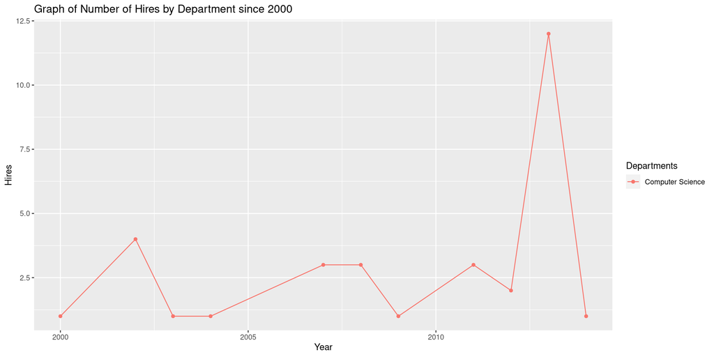

```r
hires_since_2000 <- function(depts) {
  data <- salary_data %>%
    filter(dept %in% depts,
           year(ymd(hiredate)) >= 2000) %>%
    mutate(year = year(ymd(hiredate))) %>%
    group_by(dept, year) %>%
    summarize(hires = n(), .groups = 'drop')

  ggplot(data, aes(x = year, y = hires, color = dept)) +
    geom_line() +
    geom_point() +
    labs(title = "Graph of Number of Hires by Department since 2000",
         x = "Year",
         y = "Hires",
         color = "Departments")
}

hires_since_2000("Computer Science")
```

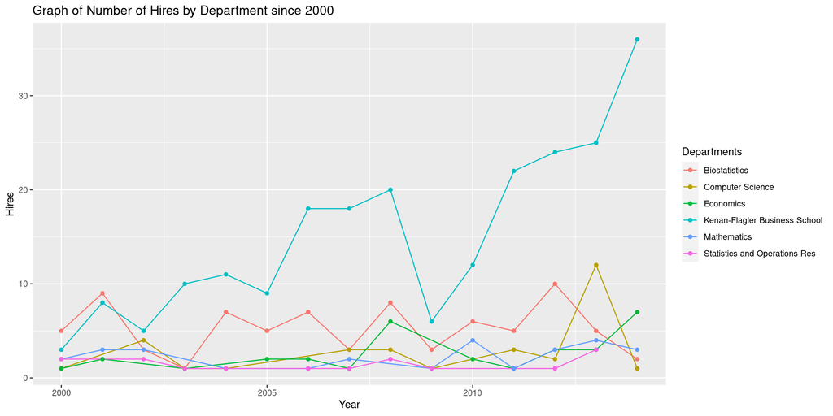

```r
departments <- c("Computer Science",
                 "Biostatistics",
                 "Economics",
                 "Kenan-Flagler Business School",
                 "Mathematics",
                 "Statistics and Operations Res")

hires_since_2000(departments)
```

### Database Connection

```r
db = dbConnect(MySQL(),
               user = 'wolffa24',
               password = '1747280',
               dbname = 'online_retailer',
               host = 'ballenger.wlu.edu')

knitr::opts_knit$set(sql.max.print = -1)
```

### Question 10

```sql
SELECT country,
       COUNT(*) AS nbr_customers
FROM customers
GROUP BY country
ORDER BY nbr_customers DESC;
```

37 records

| country | nbr_customers |
| --- | --- |
| United Kingdom | 3950 |
| Germany | 95 |
| France | 87 |
| Spain | 29 |
| Belgium | 24 |
| Portugal | 19 |
| Switzerland | 19 |
| Italy | 15 |
| Finland | 12 |
| Austria | 11 |
| Norway | 10 |
| Netherlands | 9 |
| Channel Islands | 9 |
| Australia | 9 |
| Japan | 8 |
| Sweden | 8 |
| Cyprus | 7 |
| Denmark | 7 |
| Poland | 6 |
| USA | 4 |
| Greece | 4 |
| Unspecified | 4 |
| Canada | 4 |
| Israel | 4 |
| EIRE | 3 |
| Malta | 2 |
| United Arab Emirates | 2 |
| Bahrain | 2 |
| Iceland | 1 |
| European Community | 1 |
| Czech Republic | 1 |
| Brazil | 1 |
| RSA | 1 |
| Lithuania | 1 |
| Lebanon | 1 |
| Singapore | 1 |
| Saudi Arabia | 1 |

### Question 11

```r
rs <- dbSendQuery(db,
  "SELECT country,
          customer_id,
          invoice_date,
          invoice_no AS invoice_nbr,
          SKU,
          description,
          quantity,
          actual_unit_price
   FROM products
      JOIN invoice_products USING (SKU)
      JOIN invoices USING (invoice_no)
      JOIN customers USING (Customer_Id)
   WHERE Country != 'United Kingdom'"
)

eu_countries = read.csv("/home/ballengerb@ad.wlu.edu/BUS_316_01/wolffa24/eucountries.csv")

olr_eu_product_sales <- fetch(rs, n=-1) %>%
  mutate(invoice_date = as.Date(invoice_date),
         line_item_total = quantity * actual_unit_price,
         year_month = format(invoice_date, "%Y-%m")) %>%
  filter(country %in% eu_countries$Country)
```

There are 30321 observations and 10 variables.

```r
sales_by_month <- olr_eu_product_sales %>%
  filter(!is.na(line_item_total), !year_month %in% c("2011-12", "2010-12")) %>%
  group_by(year_month) %>%
  summarize(total_monthly_sales = sum(line_item_total, na.rm = TRUE)) %>%
  arrange(year_month)

kable(sales_by_month)
```

| year_month | total_monthly_sales |
| --- | --- |
| 2011-01 | 86256.87 |
| 2011-02 | 52224.18 |
| 2011-03 | 81433.60 |
| 2011-04 | 30489.48 |
| 2011-05 | 85381.67 |
| 2011-06 | 70937.68 |
| 2011-07 | 50481.76 |
| 2011-08 | 88640.94 |
| 2011-09 | 90810.72 |
| 2011-10 | 130969.74 |
| 2011-11 | 115737.97 |

### Question 12

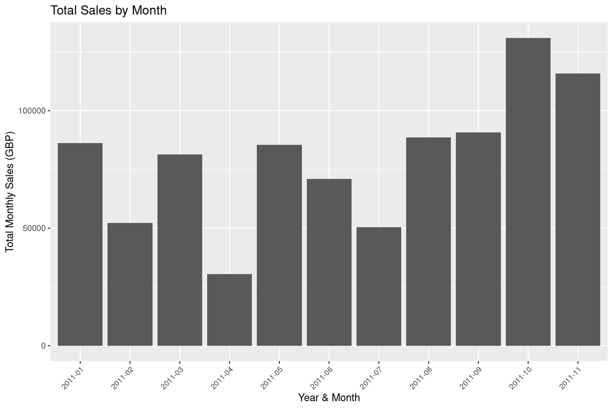

```r
ggplot(sales_by_month, aes(x = year_month, y = total_monthly_sales)) +
  geom_col() +
  labs(title = "Total Sales by Month",
       x = "Year & Month",
       y = "Total Monthly Sales (GBP)") +
  theme(axis.text.x = element_text(angle = 45, hjust = 1, size = 8))
```

### Project Log

Used the following website to find syntax for centering figures: https://yihui.org/knitr/options/

Used the following website to find arguments for ‘summarize()’: https://dplyr.tidyverse.org/reference/summarise.html

Used the following website to find syntax to angle x-axis labels: https://ggplot2.tidyverse.org/reference/theme.html

### The Pledge

On my honor, I have neither given nor received any unacknowledged aid on this assignment.

Alex Wolff, 2023-12-13